# Conformal prediction in time series with the **conformalForecast** package

Jesus U. Diaz Martinez[^1]

Paula Moraga[^2]

Spring 2025

# 1 Conformal prediction in time series

Time series forecasting is crucial in several fields, enabling better decision-making in areas such as health, environment and finance. While for some disciplines require only one step-ahead forecasts, others need multi-step ahead forecasting to predict several times ahead. For example, in disease surveillance it might be of interest to forecast the number of disease cases for each of the upcoming four weeks in advance, given available information up to the current week, with the goal of outbreak detection and optimal resource allocation. Another example is the forecasting of energy demand based on hourly data, where it might be of interest to forecast the demand of the next 24 hours to ensure supply and optimize power generation.

In this tutorial we show how to use R to obtain online conformal prediction bands for multi-step ahead forecasts of time series. For model specification, we use the **forecast** package (Hyndman et al. 2024). To obtain the conformal prediction bands, we use the **conformalForecast** package (Wang and Hyndman 2024a) that implements the online multi-step ahead conformal prediction methods from Wang and Hyndman (2024b).

Time series are an important example of scenario where exchangeability is not a realistic assumption for the data and hence coverage guarantees of usual conformal prediction methods do not hold. One of the main features of time series is the existence of temporal autocorrelation and a notion of order due its temporal nature. In addition, several methods for time series modeling and prediction are not symmetric, again, because of the temporal structure inherent to the data acquisition procedure.

For simplicity, we first consider the case of prediction of one step-ahead. Later, in Section Multi-step Conformal Prediction, multi-step prediction and its notation will be addressed. In the tutorial, time series will be denoted by $Y_t$ and is assumed to take values on a space $\textbf{Y}$. If covariates are used, they will be denoted by $\textbf{x}_t$ and will be assumed to belong to some space $\textbf{X}$. In Conformal prediction, when constructing prediction intervals for $Y_{t+1}$ based on information up to time $t$, one can consider a nonconformity measure $S(\{y_i\}_{i=1}^{t},y)$ that quantifies how different the proposed value $y$ for $Y_{t+1}$ is from the set of available data $\{y_i\}_{i=1}^{t}$. It is implicit in this nonconformity measure that there is a model or algorithm that produces predictions for $Y_{t+1}$ based on the available data. Then, we can define the nonconformity scores for the observed data as follows

$$\begin{equation}
V_{i} := S(\{y_i\}_{i=1}^{t},y_i),\quad i=1,\ldots, t,
\tag{1.1}
\end{equation}$$

and the nonconformity scores for *potential* values $y\in \textbf{Y}$ for $Y_{t+1}$ as

$$\begin{equation}
V_{t+1}^y := S(\{y_i\}_{i=1}^{t},y),\quad y\in\textbf{Y}.
\tag{1.2}
\end{equation}$$

Then, a $(1-\alpha)\times 100$% confidence prediction interval $\Gamma_{t+1}^{\alpha}$ could be constructed with the nonconformity scores obtained from the available data as follows:

$$\begin{equation}
\Gamma_{t+1}^{\alpha}:=\{y\in\textbf{Y}: V_{t+1}^y\leq \hat{q}_{\alpha}\},
\tag{1.3}
\end{equation}$$

where $\hat q_{\alpha}$ is the $\lceil (1-\alpha)(t+1) \rceil$-quantile of the nonconformity scores computed from Equation (1.1). Since for time series the exchangeability assumption is in general no longer valid, the above prediction interval is not guaranteed to provide the desired coverage.

To address the issue with exchangeability and others like the nonsymmetric algorithms, general and specially designed conformal prediction methods for time series forecasting have been recently developed. For example, the NexCP (Non Exchangeable CP) method of Barber et al. (2023) aims to extend full and split conformal prediction by introducing a weighted quantile construction of the prediction interval in Equation (1.3) to allow for more “trusted” observations to play a bigger role in the prediction step while providing approximate coverage when exchangeability does not hold and exact coverage when it does. This method is general and applies not only to time series but other instances where dependency plays a major role in the data and must not be ignored. Other approaches exists such as the EnbPI method of (Xu and Xie 2021) that employs ensembles of bootstrap models to construct the prediction intervals, one advantage of this method is the fact that it as capable of producing $h$ step-ahead prediction intervals.

## 1.1 Online conformal prediction

Another line of research called online conformal prediction is inspired by the sequential nature of time series. Online conformal prediction methods produce intervals dynamically as new data arrives by refining the significance level over time to adapt to changes in data distribution or updates to the model based on the most recent information. Specifically online conformal prediction methods estimate the significance level (or the corresponding quantile) based on the idea that the distribution of the data changes and so does the distribution of the nonconformity scores. The majority of the methods are cast as optimization problems w.r.t the quantile loss on the accumulated (or a subset of the) nonconformity scores of previous observations, like those computed in Equation (1.1), and the assumption that there exists an optimal value, $\alpha_{t+1}$, in the sense that for a prediction interval $\Gamma_{t+1}^{\alpha_{t+1}}$ for $Y_{t+1}$ constructed using $\alpha_{t+1}$ and a desired significance level $\alpha$, $P(Y_{t+1}\notin\Gamma_{t+1}^{\alpha_{t+1}})\stackrel{\sim}{=}\alpha$. As with traditional conformal prediction methods, online methods rely on the scoring of observations by means of nonconformity scores, very similar like those in Equations (1.1) and (1.2), the main difference relies on how the construction of the prediction interval is performed.

Since it is assumed that at each time there is an optimal value $\alpha_{t+1}$ that makes the prediction interval $\Gamma_{t+1}^{\alpha_{t+1}}$ for $Y_{t+1}$ achieve the desired coverage, methods for estimating such optimal value can be developed and the prediction intervals can be constructed as follows:

$$\begin{equation}
\Gamma_{t+1}(\hat\alpha_{t+1}):=\{y\in \textbf{Y}: V_{t+1}^y\leq \hat{q}_{\hat\alpha_{t+1}}\},\quad \hat{q}_{\hat\alpha_{t+1}}:= \lceil (1-\alpha_{t+1})(t+1) \rceil-\text{quantile of }\{V_i\}_{i=1}^t.
\tag{1.4}
\end{equation}$$

Here, a small change in the notation has been made to make clear that at each prediction time, there will be a dependency on the value of $\hat\alpha_{t+1}$ that is mean to track the optimal $\alpha_{t+1}$. Since at each time step new data is received and added to the existing time series, when constructing prediction bands for the next data point, this most recent observation is included as part of the available information. This process of updating the available information highlights the *online* nature of the methods, as prediction sets are continuously updated with new data.

The following steps describe the general idea behind the online construction of prediction intervals for time series when tracking the significance level. Note that the same steps apply when estimating the quantile directly by replacing the significance level by the quantile in the corresponding quantities.

1. Initialize the significance level at $\hat\alpha_1 = \alpha$.
2. For $t=1,\ldots,T$:
3. Construct prediction interval $\Gamma_{t}(\hat\alpha_t)$ using Equation (1.4).
4. Observe/receive the realization $y_{t}$ of $Y_{t}$, compute the value $\alpha_t^*:=\sup\{\alpha: y_t\in \Gamma_t(\alpha)\}$, and add the value $y_t$ to the set of available data.
5. Pay a *loss* of $\ell_{\alpha}(\hat{\alpha}_t,\alpha_t^*)$.
6. Perform the update for $\hat\alpha_{t+1}$ based on the loss obtained.
7. Go back to step 3.

The *loss* paid in step 5 is the corresponding to a parametrization of the Quantile loss, also know as Pinball loss and it has the general form

$$\rho_\alpha(u)= \begin{cases}-(1-\alpha) u & \text { if } u \leq 0 \\ \alpha u & \text { if } u > 0\end{cases},\quad u\in\mathbb{R}.$$
This loss function is standard in quantile regression problems. It is known that for a random variable $X$ the minimizer, $\hat x$, of the expectation $E(\rho_{\alpha}(X-\hat x))$, is the $1-\alpha$ quantile of the CDF of $X$, where $u$ above is replaced by $X-\hat{x}$, for more details see, for example, Chapter 1 of Koenker (2005).

In this class of methods for conformal prediction, two variations of the quantile loss function are used to compute the loss in step 5. When estimating the optimal significance level $\alpha_t^*$ the loss in step 5 takes the form

$$\begin{equation}
\ell_\alpha(\hat{\alpha}_t,\alpha_t^*):= \rho_\alpha(\alpha_t^*-\hat{\alpha}_t) = \begin{cases}-(1-\alpha) (\alpha_t^*-\hat{\alpha}_t) & \text { if } (\alpha_t^*-\hat{\alpha}_t) \leq 0 \\ \alpha (\alpha_t^*-\hat{\alpha}_t) & \text { if } (\alpha_t^*-\hat{\alpha}_t) > 0\end{cases}.
\end{equation}$$

On the other hand, if the quantile is estimated directly then the loss function is parametrized as

$$\begin{equation}
\ell_\alpha(\hat{q}_t,q_t^*):= \rho_\alpha(q_t^*-\hat{q}_t) = \begin{cases}-(1-\alpha) (q_t^*-\hat{q}_t) & \text { if } (q_t^*-\hat{q}_t) \leq 0 \\ \alpha (q_t^*-\hat{q}_t) & \text { if } (q_t^*-\hat{q}_t) > 0\end{cases},
\end{equation}$$

where $q_t^*:=\inf\{q: y_t\in\Gamma_t(q)\}$. As a remark, when using the second approach, i.e, tracking directly the quantile, the prediction interval is computed as

$$\begin{equation}
\Gamma_{t+1}(\hat{q}_{t+1}):=\{y\in \textbf{Y}: V_{t+1}^y\leq \hat{q}_{t+1}\}.
\tag{1.5}
\end{equation}$$

Each approach results in different, but similar, update rules for the step 6. One of the first works is the Adaptive Conformal Inference (ACI) method proposed by Gibbs and Candes (2021), in which the update is meant to increase the confidence level for the future prediction if the previous prediction band did not covered the current observation and to decrease it if it does. The update rule for ACI is the following

$$\hat\alpha_{t+1}=\hat\alpha_t+\gamma\left(\alpha-\operatorname{err}_t\right), \quad \operatorname{err}_t:=\begin{cases} 1, \text{ if } Y_t \notin\Gamma_t({\hat{\alpha}_t}) \\ 0, \text{ if }Y_t\in\Gamma_t(\hat{\alpha}_t)\end{cases},$$

which is derived as an Online Subgradient Descent (OSGD) algorithm applied to the loss

$$\ell_{\alpha}(\hat\alpha_t,\alpha_t^*):=\rho_{\alpha}(\alpha_t^*-\hat\alpha_t),$$

w.r.t $\hat\alpha_t$, where $\alpha_t^*:=\sup\{\alpha:y_t\in\Gamma_t(\alpha)\}$. In this case, the subgradient of the loss function $\ell_{\alpha}(\hat\alpha_t,\alpha_t^*)$ is $\alpha-\operatorname{err}_t$. This update depends on a *learning* rate parameter $\gamma$ that controls how fast this rule will adapt to the miscoverage events, which needs tuning to perform well as very low values will result in not being able to track the correct coverage or produce overly conservative prediction bands if the value of $\gamma$ is too large. However the attractive feature of this method is that it does not rely on any assumption of the temporal dependence of the data, which makes it suitable for wrapping it in any forecast model and the coverage guarantees are obtained asymptotically without any assumption on the model structure.

Further extensions of the idea behind ACI have been developed. For example, to avoid the manual tuning of the learning rate parameter, Zaffran et al. (2022) proposed a method for aggregation of *experts*, where the experts are ACI algorithms with a particular value of the learning rate. Similar to this work is that of Bhatnagar et al. (2023), where they use a more theoretically backed method for expert aggregation that allows not only better theoretical guarantees on the coverage but also on the type of prediction intervals since their approach rules out trivial solutions that ACI was not able to exclude, in addition their method is able to produce prediction intervals for predictions of several steps ahead in a batch style. In addition, the approach proposed by Bhatnagar et al. (2023) tracks directly the corresponding quantile at the desired significance level instead of the significance level, then its algorithm performs the update

where $\hat{q}_t$ is the $(1-\alpha)\cdot 100\%$ quantile of the nonconformity scores and $\Gamma_t(\hat{q}_t)$ is the prediction band for $Y_t$ based on the quantile $\hat{q}_t$. Such update rule is derived also as an OSGD update on the loss

$$\ell_{\alpha}(\hat{q}_t,\operatorname{q}^*_t):=\rho_{\alpha}(\operatorname{q}^*_t-\hat{q}_t),$$
with $\operatorname{q}^*_t:=\inf\{q:Y_t\in \Gamma_t(q)\}$.

An implicit assumption on the previous methods is the fact that the trained model makes the best use of the information in the data so they perform good predictions. Challenging this assumption Angelopoulos, Candès, and Tibshirani (2023) developed a method (PID) to deal with *remaining* information in the nonconformity scores. Their method is built on top of the ideas of optimal control and, as they state, it is a combination of a quantile tracker, similar to that of ACI; an error integrator, which is simply the running sum of miscoverage indicator variables minus the target coverage level; and a *scorecasting* that aims to account for systematic trends in the nonconformity scores. The update rule is as follows

$$\hat{q}_{t+1}=\hat{q}_t+\eta\left(\operatorname{err}_t-\alpha\right)+r_t\left(\sum_{i=1}^t\left(\operatorname{err}_i-\alpha\right)\right).
\tag{1.6}$$

## 1.2 Multi-step Conformal Prediction

The methods described previously are not able to generate prediction intervals for multi-step ahead forecasts as they are designed for constructing prediction intervals for $Y_{t+1}$ given available information up to the previous time point $t$. To address the limitations of the previous methods, Wang and Hyndman (2024b) introduce some generalizations for multi-step ahead prediction intervals to some of the methods previously mentioned and proposed a new approach that integrates autocorrelations present in the nonconformity scores. The main observation of their work is the fact that multi-step ahead predictions are usually correlated, in particular under the assumption of a general non-stationary autoregressive process of additive form, the forecasts errors can be approximated as a MA(h-1) process, where $h$ is the forecasting horizon. Their method, developed on top of the work by Angelopoulos, Candès, and Tibshirani (2023), incorporates an extra term to the update rule of Equation (1.6), denoted by $\tilde e_{t+h\lvert t}$ that accounts for autocorrelation in the nonconformity scores. This extra term is the combination of a MA($h-1$) model trained on the $h$-step ahead forecast errors and a linear regression model trained to regress the $h$-step ahead error from the past $h-1$ errors.

This method, in contrast to the PID, allows for multi-step ahead prediction however, by construction of the method, it is restricted to models with an additive structure (but no assumption on the dependency structure are imposed) and therefore to use the (signed) forecast deviations (residuals) as nonconformity measure. Before presenting the corresponding update rule and associated quantities like the nonconformity scores, a critical idea, *online learning with sequential splits*, will be introduced.

In the previous subsection the online learning paradigm to constructing prediction intervals was presented, an important step was that of rolling over the recently received/observed data to construct the prediction interval for the next data point. For the multi-step ahead method it will be assumed that there are $N$ available observations and predictions will start at $t=N+1$. In addition, forecasting $H$-steps-ahead is of interest, with $N>>H$. The available data will be split into proper training of size $t_r$ and proper calibration set of size $N-t_r>H$, the latter will consists of the true observarions $\{y\}_{t = t_r+1}^{N}$ used to generate nonconformity scores. The training data of size $t_r$ will be used to fit a model and make predictions for $H$ steps-ahead. Then these predictions will be compared to the corresponding true observations in the calibration set, and then the window of size $t_r$ will be rolled one data point and the process of training and prediction will start again until the nonconformity scores on all the calibration data have been computed. With this idea, the nonconformity score for the $h-$step-ahead prediction on the calibration data can be defined as
$$S(\{Y\}_{j=t-t_r + 1}^{t}, Y_{t+h}), \quad \text{for } t_r\leq t \leq N;\quad h=1,\ldots,H.$$
with corresponding nonconformity score as

$$V_{t+h\lvert t} := S(\{y\}_{j=t-t_r + 1}^{t}, y_{t+h}), \quad \text{for } t_r\leq t \leq N;\quad h=1,\ldots,H.$$
Given the assumptions in Wang and Hyndman (2024b), the nonconformity measure is the following

$$S(\{Y\}_{j=t-t_r + 1}^{t}, Y_{t+h}) := Y_{t+h} - \hat{Y}_{t+h\lvert t},$$
where $\hat Y_{t+h\lvert h}$ is the prediction of $Y_{t+h}$ using data up to time $t$, i.e, $\{Y\}_{j=t-t_r + 1}^{t}$.

For the construction of the prediction intervals the corresponding nonconformity measures for a possible value $y\in \textbf{Y}$ for $Y_{t+h}$ with $t>N$, can be defined as

$$V^y_{t+h\lvert t} = S(\{Y\}_{j=t-t_r+1}^t,y), \quad \text{for }y\in \mathbb{R}.$$

A few remarks are important in the notation above. As some models might include covariates in addition of the time series itself, we denote data as $z_t$ and this may include only the time series or both the time series and covariates. Specifically, the sequence of data can be of the following forms:

- Only time series $\{y\}_{j=t-t_r + 1}^{t}$, and $z_t=y_t$.
- Time series with covariates $\{(y_t, \textbf{x}_t)\}_{j=t+t_r+1}^{t}$ and $z_t=(y_t, \textbf{x}_t)$, where the covariates may include not only information up to the *current* time but also information about the following $h$ steps ahead, which are of interest.

In the following, we will assume the following notation for the nonconformity measure, and hence the nonconformity scores, that accomodate for the two scenarios above.

$$S(\{Z_t\}_{j=t-t_r + 1}^{t}, Y_{t+h}), \quad \text{for } t_r\leq t \leq N;\quad h=1,\ldots,H.$$

The steps for the multi-step-ahead conformal prediction will be the following:

1. **Initialization**: Obtain the initial proper training set by selecting the sequence of points $\{z_k\}_{k=1 + t - t_r}^{t}$ by setting $t = t_r$ and fit the model. Then obtain $H$-step-ahead point forecasts $\{\hat{y}_{t+h\lvert t}\}_{h=1}^H$ and compute the corresponding nonconformity scores $\{V_{t+h\lvert t}\}_{i=1}^{H}$.
2. **Rolling procedure**: Roll the training window of size $t_r$ by one point at a time by setting $t\to t+1$, for $t_r\leq t\leq N$. Then repeat step one until the nonconformity scores, $\{V_{t+h\lvert t}\}_{t=t_r}^{N-H}$ for each $h=1,\ldots,H$, have been computed on the entire calibration set.
3. **Prediction interval construction**: Use the nonconformity scores obtained from the previous step to compute quantile estimates $\hat{q}_{t+h\lvert t}$ for each forecasting horizon $h=1,\ldots,H$. Then compute prediction intervals $\Gamma_{t+h\lvert t}(\hat{q}_{t+h\lvert t}):=\{y\in\textbf{Y}: V_{t+h\lvert t}^y \leq \hat{q}_{t+h\lvert t}\}$, with $t=N$ and for each $h=1,\ldots, H$.
4. **Online update**: Update the calibration and the training set by rolling one data point at a time every time a new data point is received, then update the nonconformity scores based on the new calibration set and then repeat step 3.

The quantile $\hat{q}_{t+h\lvert t}$ in step 3 above corresponds to the estimated quantile using the method of Wang and Hyndman (2024b). Such approach proposes the update rule

$$\hat{q}_{t+h\lvert t}=\hat{q}_{t+h-1\lvert t-1}+\eta\left(\operatorname{err}_{t\lvert t-h}-\alpha\right)+r_t\left(\sum_{i=h+1}^t\left(\operatorname{err}_{i\lvert i-h}-\alpha\right)\right) + \tilde e_{t+h \lvert t},
\tag{1.7}$$

where $\tilde e_{t+h\lvert t}$ is a term that accounts for autocorrelation in the nonconformity scores and is the combination of a MA($h-1$) model trained on the $h$-step ahead forecast errors and a linear regression model trained to regress the $h$-step ahead error from the past $h-1$ errors. $\operatorname{err}_{t\lvert t-h}$ is defined as

$$\operatorname{err}_{t\lvert t-h}:=\begin{cases}
1,\quad \text{if } y_t\notin \Gamma_{t\lvert t-h}(\hat{q}_{t\lvert t-h})\\
0, \quad\text{otherwise}
\end{cases},$$

$\eta>0$ is a constant learning rate and $r_t$ is a *saturation* function that satisfies the conditions

$$x\geq c\cdot g(t-h)\Rightarrow r_t(x)\geq b,\quad \text{and}\quad x\leq -c\cdot g(t-h)\Rightarrow r_t(x)\leq-b,$$

for some constant $b,c>0$ and a function $g$ that is sublinear, nonnegative and nondecreasing. These conditions are required to establish the asymptotic coverage guarantees.

## 1.3 Implementation of multi-step ahead conformal prediction in the **conformalForecast** package

Several of the methods described previously are available as R packages but unfortunately none of them is available on CRAN yet. The **conformalForecast** package (Wang and Hyndman 2024a) implements the method developed by Wang and Hyndman (2024b) and some extensions of others like the ACI and PID. An attractive feature of the design of this package is the attempt to separate the model specification and fitting from the conformal prediction step, which aligns with the ideas of conformal prediction of being flexible and capable of being wrapped around almost any model. In particular, the functions for conformal prediction require that the user provides a function that will produce predictions (a model), later this function will be used to get prediction on the (online) calibration set and finally we will be able to construct conformal prediction intervals with any of the methods implemented in the package. The non-conformity score implemented for conformal prediction in the **conformalForecast** package is the (signed) forecast errors, i.e,

$$S(\{Z\}_{j=t-t_r + 1}^{t}, Y_{t+h}) := Y_{t+h} - \hat{Y}_{t+h\lvert t}.$$

Most of the functions for the available online conformal prediction methods in the **conformalForecast** package allow two types of intervals: symmetric and non-symmetric. The symmetric prediction intervals are constructed using the absolute value of the nonconformity measure above and hence the prediction intervals have the form

$$\left[\hat{Y}_{t+h} - \hat{q}_{t+h\lvert t}, \hat{Y}_{t+h} + \hat{q}_{t+h\lvert t}\right]$$
where $\hat{Y}_{t+h}$ is the forecast for the $h$-step ahead and $\hat{q}_{t+h\lvert t}$ is estimated quantile produced by applying the update rule in Equation (1.7).

For the asymmetric quantiles the update rule in Equation (1.7) is applied to the nonconformity scores defined above as follows:

1. For the upper limit of the prediction interval, the update rule tracks the quantile at level $100\times(1-\alpha/2)$, denoted as $\hat{q}_{t+h\lvert t}^{\operatorname{upper}}$, on the nonconformity scores above using the update rule of Equation (1.7).
2. For the lower limit of the prediction interval, the update rule tracks the quantile at level $100\times(1-\alpha/2)$, denoted by $\hat{q}_{t+h\lvert t}^{\operatorname{lower}}$ on the nonconformity scores resulting from the nonconformity measure above but multiplied by -1, i.e, $\tilde S(\{Z\}_{j=t-t_r + 1}^{t}, Y_{t+h}) := \hat{Y}_{t+h\lvert t} - Y_{t+h}$ using the update rule of Equation (1.7).
3. The prediction intervals for each forecasting horizon are constructed as follows
   $$\left[\hat{Y}_{t+h} - \hat{q}_{t+h\lvert t}^{\operatorname{lower}}, \hat{Y}_{t+h} + \hat{q}_{t+h\lvert t}^{\operatorname{upper}}\right]$$

Since the package is not available via the CRAN, it can be installed using the following command.

```r
# install.packages("remotes")
remotes::install_github("xqnwang/conformalForecast")
```

## 1.4 Outline for the remaining sections of the tutorial

In the remainder of the tutorial, we provide a description of the data considered and of the main functions in the **conformalForecast** package, in addition of its main arguments. We will use the **forecast** package to construct a function to produce forecasts, and will provide some comments about the main ideas for the general construction of custom forecast functions. Then, we will use the **conformalForecast** package to generate conformal prediction intervals for 1 to 4 steps-ahead forecasts. Finally, we also show how to visualize the results and how to obtain evaluation of the results.

# 2 Conformal prediction for dengue cases forecasts in Brazil

In our example, we consider a time series of the weekly number of [dengue cases](https://github.com/uriel278/tutorials-cp) in Sao Paulo, Brazil. This data has been obtained from the surveillance system [InfoDengue](https://info.dengue.mat.br) (Codeco et al. 2018) and contains the number of dengue cases for 678 weeks from 2010 to 2022 (52 weeks each year from 2010 to 2022 except 2012 and 2017 with 53 weeks).

## 2.1 Data preparation

We read the dengue time series data with `read.csv()`, then we use the `ts()` function to create a time series object with the weekly number of cases. As mentioned above, there are two years in which the number of observations is 53 instead of 52. In the `ts()` function, we specify the `frequency` argument as `frequency = 52` only for visualization purposes. This choice simplifies the visualization, even though some years have 53 weeks. An alternative approach could involve using a `frequency = 52.28571` to account for leap years or imputing the 53rd week’s data by averaging it with the 52nd week if this is appropriate in the context of the problem and data at hand. However, for this tutorial, we prioritize simplicity and clarity in illustrating how to calculate intervals, so we proceed with `frequency = 52`. In the model building step (see section Modeling and prediction), the `frequency` argument is not used, as seasonality is explicitly defined in the model. If the model were to depend on this argument, the user would need to adjust the frequency accordingly to obtain valid results.

A summary of the data shows weekly dengue cases range from 38 to 12367 cases.

```r
library(here)
d.dir <- here("data", "dengue.csv")
d <- read.csv(d.dir)
d <- ts(d$x, start = c(2010, 1), frequency = 52)
summary(d)
```

```
##    Min. 1st Qu.  Median    Mean 3rd Qu.    Max.
##    38.0   126.5   232.0   563.8   459.0 12367.0
```

## 2.2 Splitting data

The **conformalForecast** package splits the data automatically, for this example we consider the data from 2010-2011 as our initial training data, 2012-2013 as the calibration set, and 2014-2022 as the prediction set. In the Prediction bands section it is explained how this is done with the corresponding functions of the **conformalForecast** package. For the moment we can visualize the initial split by specifying these sets using the `window()` function and providing the start and end dates considered in each data split.

```r
dtrain <- window(d, start = c(2010, 1), end = c(2011, 52))
dcal <- window(d, start = c(2012, 1), end = c(2013, 52))
dtest <- window(d, start = c(2014, 1))
```

The resulting initial splits are displayed in the Figure 2.1 below, each one with a different color.

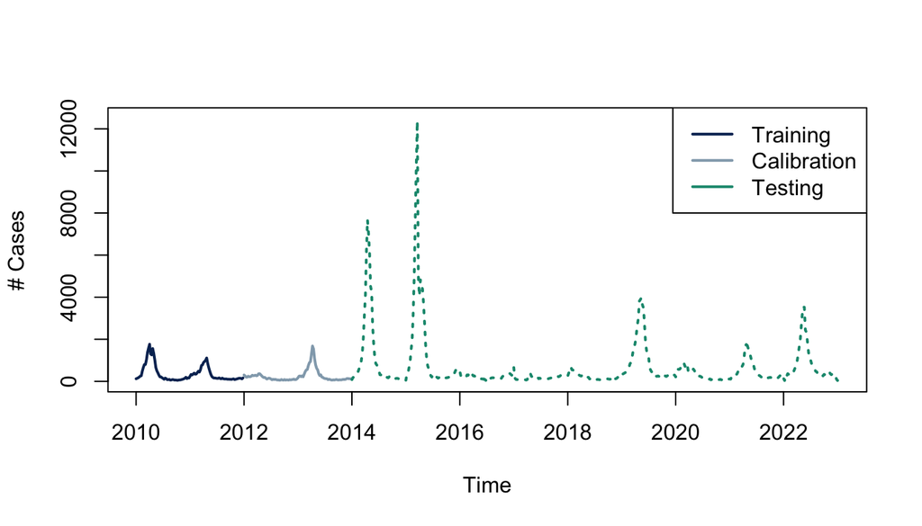

Figure 2.1: Splits of the dengue time series for the example. The initial training split (in blue) with two years of data, calibration set (in gray) and the testing set in dashed green lines.

```r
cols <- c('#052F61', '#92A9B9', '#14967C')
plot(d*NA, ylim = c(0, 12500), ylab = "# Cases")
lines(dtrain, col = cols[1], lwd = 2)
lines(dcal, col = cols[2], lwd = 2)
lines(dtest, col = cols[3], lwd = 2, lty = 3)
legend('topright', legend=c('Training','Calibration', 'Testing'),
       col = cols, lty = 1, lwd = 2)
```

## 2.3 Modeling and prediction

The **conformalForecast** package to compute uncertainty intervals attempts to separate the model specification and fitting from the conformal prediction step. In particular, it requires that the user provides a function that produces predictions which is later used to get predictions on the calibration set. Then, using these predictions, nonconformity scores are computed to construct conformal prediction intervals.

It is important to remark that the main function from the **conformalForecast** package, `cvforecast()`, does not require to pass the splits of the data, the splits generated above are only for visualization purposes. The `cvforecast()` function computes the splits following the sequential split framework described in the Multi-step Conformal Prediction section.

### 2.3.1 The `cvforecast()` function

As previously mentioned, `cvforecast()` is the main function of the **conformalForecast** package. In this function the user must provide the data via the `y` argument, a function to produce prediction with the `forecastfun` argument, the forecasting horizon `h`, and the confidence level `level` for the prediction interval. The `level` argument admits a single value or a vector to be able to compute intervals with several levels of confidence. Since the results of this function are used later by the functions that implement the methods to compute prediction intervals care must be take as not all of the methods behave well when a vector of significance levels is passed to the `cvforecast()` function, some of them will return `NA` values for the prediction bands without warning the user that vector arguments are not supported while correct results will be returned if only a single value is provided and this is not indicated in the available documentation.

Additional arguments include `forward = TRUE` which indicates if the forecast is going to be performed using information up to $y_{T}$ or up to $y_{T-1}$ if `forward = FALSE`. If additional covariates are required by the `forecastfun` function, these must be provided via the `xreg`. The argument `initial` indicates the index $t$ of the observation $y_t$ in the time series where the computations will start. For example, if for some reason the user needs to avoid computation on the first 10 observations of the time series, the argument can be set to `initial = 11` so the function will avoid the computations on the previous 10 data points. By default `initial = 1` to indicate that computations must start from the beginning. A`window` parameter must be provided to indicate that a rolling training window is going to be used and the user must provide a value (greater than 1) to indicate the size.

This function will apply the `forecastfun` to the data and will compute the predictions for each forecasting horizon given sequential information based on sequential splits and will compute nonconformity scores, in this case the residuals. The returned object will be of class `cvforecast` and `forecast`.

This function only computes quantities that are required by the Conformal Prediction methods available in the package, it does not computes any prediction bands based on conformal prediction. However, if the `forecastfun` computes prediction bands, these will be saved in the returned object.

An example of a call to the `cvforecast()` function is the following.

```r
pred <- cvforecast(y = d, forecastfun = forecastfunction, h = 4, level = 95, window = 52*2)
```

where the data is the dengue cases time series stored in the variable `d`, a forecasting function, `forecastfunction()`, is provided with the argument `forecastfun`, this will be explained with more detail in the following subsection, four step-ahead forecasts are indicated with `h = 4`, and `level = 95` for the prediction bands generated by the `forecastfun` and a training window of size `window = 52*2` that corresponds to two years of data in our example.

### 2.3.2 Model specification and the `forecastfun` argument

We start by specifying the function to obtain predictions. Here, we use a SARIMA model as in the plots we can observe some temporal patterns that repeat over time. The model for the time series $Y_t$ is of the form:

$$\Phi_P(B)\phi_p(B)\nabla^{d}\nabla^{D}_{S}Y_t=\Theta_{Q}(B)\theta_q(B)W_t,$$

where $B$ is a lag operator, $\Phi(\cdot)$ and $\phi(\cdot)$ are the seasonal autoregressive and autoregressive polynomials of order $P$ and $p$, respectively; $\Theta_Q(\cdot)$ and $\theta_q(\cdot)$ are the seasonal moving average and moving average polynomials of order $Q$ and $q$, respectively; $\nabla^D_S$ and $\nabla^d$ are the seasonal difference and difference operators of order $(D,S)$ and $d$, respectively, and $W_t$ is a white noise process. For more details about the SARIMA model, see Brockwell and Davis (2016).

The code below shows how to specify a forecast function called `forecastfunction()` using the `Arima()` function of the **forecast** package. `forecastfunction()` is going to be passed to `cvforecast()` to compute forecasts as the `forecastfun` argument. This function needs to accept a dataset `x`, the number of steps ahead `h` to predict, and the confidence level `level`. In order to use such function as the `forecastfun`, compatibility must be guaranteed and in order to ensure this, it is mandatory that the `forecastfun` accepts at least these three arguments with those names (`x`, `h`, `level`), otherwise errors will appear when calling the `cvforecast()` function. Note that this does not poses a limitation in the forecasting models that can be used as the user can always create a wrapping function to the model of interest in such a way that the three basic arguments of any valid forecast function are assigned to the corresponding ones in the main function of the model to be used. In our example this has been done by joining the `Arima()` function, which expects a dataset as argument and other arguments for model specification, and the `forecast` function, which requires the steps-ahead to forecasts in addition to the `level`. Furthermore, note that before the prediction/forecast step we fit the model. This not a mandatory step, we may have an already fitted model and can call only the corresponding prediction function. A complete example of the `forecastfunction()` is the following.

```r
library(forecast)
forecastfunction <- function(x, h, level){
  Arima(x, order = c(1, 0, 1),
    seasonal = list(order = c(1, 0, 2), period = 11),
    method = "ML") |>
    forecast(h = h, level = level)
}
```

We can verify that this function is working well by calling it on some data. Specifically, we can use the data in the `dtrain` time series to predict four steps-ahead and produce 95% confidence prediction intervals. Note that this intervals are generated by the `forecast()` function of **forecast** package on the the object created by the `Arima()` function and not by any Conformal Prediction method.

```r
forecastfunction(dtrain, 4, 95)
```

```
##          Point Forecast       Lo 95    Hi 95
## 2012.000       202.3508    4.851264 399.8504
## 2012.019       218.0348 -126.807301 562.8770
## 2012.038       242.6809 -189.294166 674.6559
## 2012.058       252.1177 -241.779970 746.0153
```

## 2.4 Prediction bands

Now that the `cvforecast()` function has been explained as well as the `forecastfun` argument, we can proceed to obtain prediction intervals with conformal prediction. The first step is to call the `cvforecast()` function with the required arguments. This is done with the following command sequence.

```r
library(conformalForecast)
pred <- cvforecast(d, forecastfunction, h = 4, level = 95, initial = 1, window = 52*2)
```

Once the forecasts have been obtained using `cvforecast()`, we get prediction intervals powered by conformal prediction. The **conformalForecast** package implements different online conformal prediction algorithms, see Wang and Hyndman (2024b) for more details and the list of available algorithms.

In this tutorial, we use the multistep-ahead conformal prediction (MCP) method developed by the authors, which is available through the `mcp()` function and computes the update rule described in the section Multi-step Conformal Prediction. The first argument of `mcp()` is the result from the `cvforecast()` function, which in our case is `pred`. We also need a calibration set size which we set to `ncal = 52*2` to be consistent with setting the data of the years 2012-2013 as calibration set. We set `rolling = TRUE` to use a rolling window for the construction of the quantile. Note that the size of the rolling depends on the `window` parameter provided in the `cvforecast()` function and with our size of the calibration size, this agrees with setting the data from the years 2010-2011 as initial training set and the data from 2012-2013 as calibration set as described at the beginning of the Splitting data subsection.

The `mcp()` function also has a number of parameters whose specification is detailed in Wang and Hyndman (2024b). Briefly, we can provide a learning rate parameter `lr`, which in our case is set to `lr = 0.1`. The parameter called `KI` is particular to the method proposed by the authors of the package. This parameter is related to the maximum size of the non-conformity scores (which is the absolute deviation). Therefore, if we have a guess of the size of the nonconformity score we can provide it as this parameter, in our case we will set it to `KI = 2000`. Finally, the parameter `Csat` depends on the length of the time series by guaranteeing that by time $T$, the absolute coverage guarantee is of at least $1-\alpha-\delta$. This $\delta$ that *reduces* the desired coverage guarantee is there because the coverage guarantees are asymptotic and not conservative on finite sample size as traditional conformal prediction methods. This amount of *reduced* coverage, $\delta$, is *controlled* by the argument `delta` and we can think about it as the amount of coverage we are willing to loose given that we can not observe the process for an infinite period of time. The expression for the value of `Csat` below has been obtained from appendix C in Angelopoulos, Candès, and Tibshirani (2023).

```r
Tg <- length(d)
delta <- 0.01
Csat <- 2 / pi * (ceiling(log(Tg) * delta) - 1 / log(Tg))

band <- mcp(pred, ncal = 52*2, rolling = TRUE,
            lr = 0.1, KI = 2000, Csat = Csat)
```

### 2.4.1 Plot predictions and prediction bands

We plot the corresponding prediction bands for each forecasting horizon as follows and the result is displayed in Figure 2.2. We can observe that the width of the prediction intervals growths as the forecasting horizon increases, this is an expected behavior as less information is available.

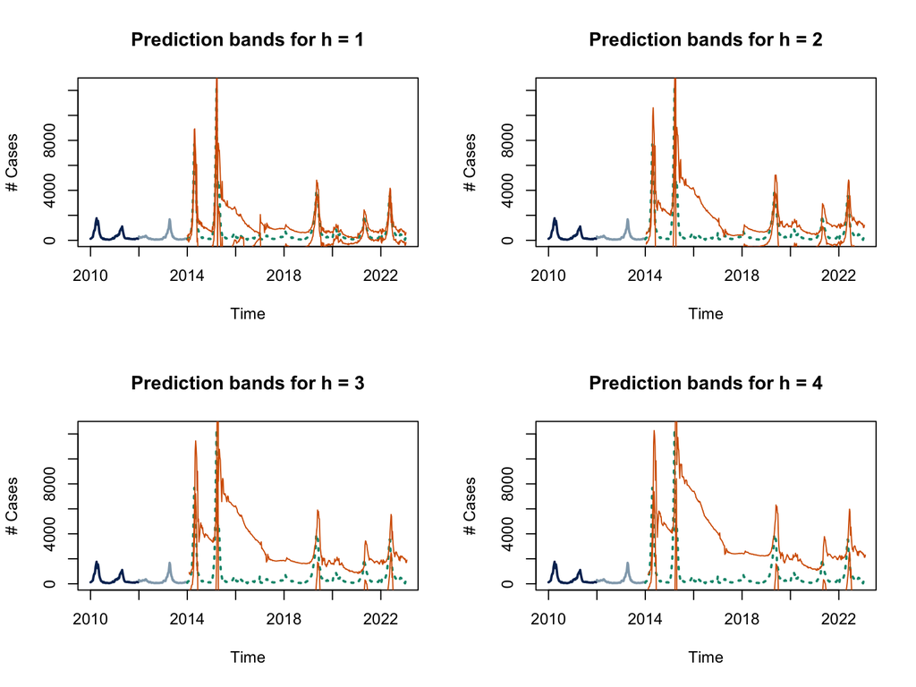

Figure 2.2: Prediction bands (in orange) using MCP on the dengue data for each forecasting horizon.

```r
par(mfrow = c(2, 2))
for(h in 1:4){
plot(d*NA, ylim = c(0, 12500), ylab = "# Cases",
     main = paste("Prediction bands for h =", h))
lines(dtrain, col = cols[1], lwd = 2)
lines(dcal, col = cols[2], lwd = 2)
lines(dtest, col = cols[3], lwd = 2, lty = 3)
lines(band$LOWER$`95%`[, h], col = "#D55E00")
lines(band$UPPER$`95%`[, h], col = "#D55E00")
}
```

## 2.5 Evaluation coverage prediction bands

We can also calculate the coverage probabilities for the conformal predictions bands. The `coverage()` function from **conformalForecast** provides methods for computation of the empirical coverage. For example, we can get the empirical mean coverage over the whole period for each forecasting horizon by passing the `band` object containing the returned conformal predictor and the target confidence level as arguments. We can also evaluate the evolution of the coverage for each forecasting horizon by using a rolling mean given a determined window size. Here, we set the argument `window = 52` to generate a moving window evaluation of the coverage for each forecasting horizon, which corresponds to a yearly moving window for the dengue data.

```r
covmodel <- coverage(band, level = 95, window = 52)
```

The global coverage for each forecasting horizon can be obtained as follows. And after inspecting them we can see that the method follows quite close the desired target coverage.

```r
100*covmodel$mean
```

```
##      h=1      h=2      h=3      h=4
## 94.68085 92.30769 94.20601 93.96552
```

In addition, we can visualize the evolution of the coverage for each horizon using the following code. The results, displayed in Figure 2.3, show empirically by means of the running mean empirical coverage how the method tracks the desired coverage. We can observe that at the beginning of the iterations the coverage corresponding to the one-step ahead is higher than those from the other horizons; this is expected as the information up to time $t$ is expected to be more relevant to predict the next step compared to predicting the next ones. However, after more iterations, the method is capable of learning how to track the desired coverage for each horizon and the traces oscilate around the desired target. It is important to note that as with these methods the coverage is no longer conservatively valid but asymptotically valid, the traces will exhibit such oscilations around the target coverage.

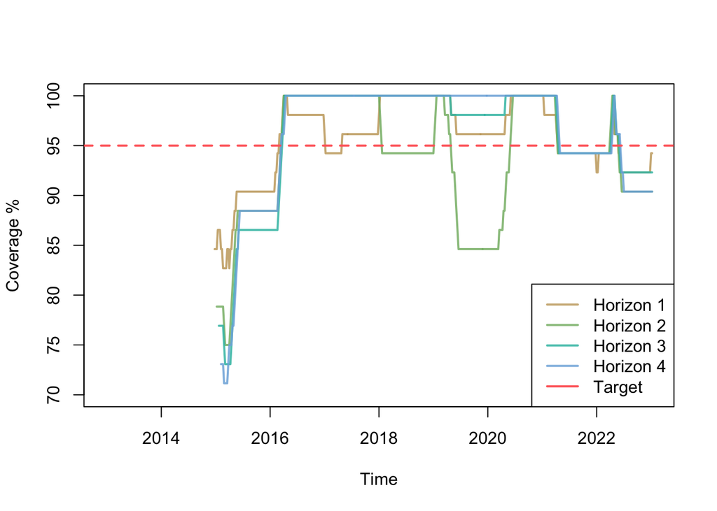

Figure 2.3: Trace of the running mean empirical coverage on the dengue time series for each forecasting horizon and the target coverage with a red dashed line at 95% confidence.

```r
colsh <- hcl.colors(4, alpha = 0.85, palette = "Harmonic")
plot(100*covmodel$rollmean[, 1], lwd = 2, col = colsh[1],
     ylim = c(70, 100),  ylab = "Coverage %")
lines(100*covmodel$rollmean[, 2], lwd = 2, col = colsh[2])
lines(100*covmodel$rollmean[, 3], lwd = 2, col = colsh[3])
lines(100*covmodel$rollmean[, 4], lwd = 2, col = colsh[4])
abline(h = 95, col = "indianred1", lwd = 2, lty = 2)
legend("bottomright", legend = c(paste("Horizon", 1:4), "Target"),
       col = c(colsh, "indianred1"), lwd = rep(2, 5))
```

# 3 Conclusions

The **conformalForecast** package allows us to perform multi-step ahead conformal prediction on time series data. It allows for flexible algorithms for prediction and implements a variety of online conformal prediciton methods for time series. On the other hand, the package presents a number of limitations. The most important is the restriction to the absolute deviation as non-conformity measure. Currently, the package does not include options for selecting a different non-conformity measure neither functions/interfaces to define alternative non-conformity measures and its corresponding behavior to construct intervals given the estimated quantile. An additional major limitation is the full dependence of the `cvforecast()` function, as the user must pass the complete dataset in order to be able to apply the methods; even when this work is based on the ideas of online learning the implementations do not fully allow its incorporation on streams of data. For example, the user might have data available up to time $t = N$, and then using the methods of the package prediction intervals for the forecasts of $Y_{N+1},\ldots, Y_{N+H}$ can be obtained, however when the observation $y_{N+1}$ is received, the user must add it to the time series and then run all the code again but on this *augmented* time series, which is redundant as most of the computations have been carried out already and only an update of both the object returned by the `cvforecast` and the prediction intervals of the chosen methods are necessary. Further enhancements of the package might address such limitations.

Angelopoulos, Anastasios N, Emmanuel J Candès, and Ryan J Tibshirani. 2023. “Conformal PID Control for Time Series Prediction.” In. Curran Associates, Inc.

Barber, Rina Foygel, Emmanuel J. Candès, Aaditya Ramdas, and Ryan J. Tibshirani. 2023. “Conformal Prediction Beyond Exchangeability.” *The Annals of Statistics* 51 (2). https://doi.org/10.1214/23-AOS2276.

Bhatnagar, Aadyot, Huan Wang, Caiming Xiong, and Yu Bai. 2023. “Improved Online Conformal Prediction via Strongly Adaptive Online Learning,” Proceedings of the 40 th International Conference on Machine Learning,.

Brockwell, Peter J., and Richard A. Davis. 2016. *Introduction to Time Series and Forecasting*. Springer International Publishing. https://doi.org/10.1007/978-3-319-29854-2.

Codeco, C., F. Coelho, O. Cruz, S. Oliveira, T. Castro, and L. Bastos. 2018. “Infodengue: A Nowcasting System for the Surveillance of Arboviruses in Brazil.” *Revue d’Épidémiologie Et de Santé Publique* 66 (July): S386. https://doi.org/10.1016/j.respe.2018.05.408.

Gibbs, Isaac, and Emmanuel Candes. 2021. “Adaptive Conformal Inference Under Distribution Shift.” In, 34:16601672. Curran Associates, Inc. https://proceedings.nips.cc/paper/2021/hash/0d441de75945e5acbc865406fc9a2559-Abstract.html.

Hyndman, Rob, George Athanasopoulos, Christoph Bergmeir, Gabriel Caceres, Leanne Chhay, Mitchell O’Hara-Wild, Fotios Petropoulos, Slava Razbash, Earo Wang, and Farah Yasmeen. 2024. “Forecast: Forecasting Functions for Time Series and Linear Models.” https://pkg.robjhyndman.com/forecast/.

Koenker, Roger. 2005. “Quantile Regression.” https://doi.org/10.1017/cbo9780511754098.

Wang, Xiaoqian, and Rob Hyndman. 2024a. “conformalForecast: Conformal Prediction Methods for Multistep-Ahead Time Series Forecasting.”

Wang, Xiaoqian, and Rob J. Hyndman. 2024b. “Online Conformal Inference for Multi-Step Time Series Forecasting,” no. arXiv:2410.13115 (October). http://arxiv.org/abs/2410.13115.

Xu, Chen, and Yao Xie. 2021. “International Conference on Machine Learning.” In, 11559–69. PMLR. https://proceedings.mlr.press/v139/xu21h.html.

Zaffran, Margaux, Olivier Feron, Yannig Goude, Julie Josse, and Aymeric Dieuleveut. 2022. “International Conference on Machine Learning.” In, 25834–66. PMLR. https://proceedings.mlr.press/v162/zaffran22a.html.

[^1]: KAUST
[^2]: KAUST